# Ford GoBike System Data Exploration

## Dataset Overview

> The data consists of information about individual rides made in a bike-sharing system covering the greater San Francisco Bay area.

## (Visualization 1)

> This first visualization shows the count of bike rides across the combined weekly basis for this month of february. It shows that Thursday has the highest bike ride count with a gradual regression across the week, with weekends of Saturday & Sunday being the least occupied days for usage.

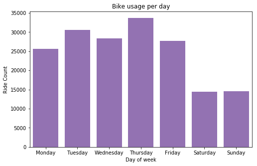

## (Visualization 2)

> Using a Boxplot it show the distribution of the age range across the various periods of the day. As can be seen across all periods the major density of each lies within the ages of 25-40 years of age.

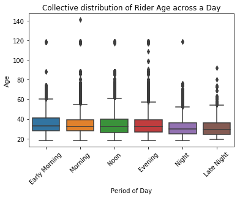

## (Visualization 3)

> Lastly, a scatterplot comparing the ride duration with the Age range across each day in the week. The purpose of this was to get an overall view of how much the day of the week played a factor in which age range had the most bike rides as well as how long the duration was.

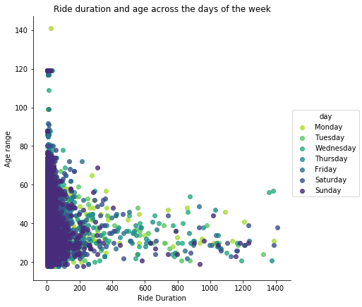